# Data Engineering- Module 4: BigQuery Features

1) OLAP vs OLTP  
2) Partitioning and Clustering in BigQuery  
3) BigQuery Best Practices

# 1) OLAP vs OLTP

## Online Analytical Processing (OLAP)

Online analytical processing (OLAP) is a system for performing multi-dimensional analysis at high speeds on large volumes of data. Typically, this data is from a data warehouse, data mart or some other centralized data store. It allows users to quickly and interactively analyze data from multiple perspectives and make informed decisions based on that analysis. OLAP is ideal for data mining, business intelligence and complex analytical calculations, as well as business reporting functions like financial analysis, budgeting and sales forecasting.

The core of OLAP is the multidimensional data model, which organizes data into dimensions and measures. Dimensions represent the different ways in which data can be analyzed, such as time, geography, or product, while measures represent the numeric values to be analyzed, such as sales revenue or profit margin. The multidimensional data model enables users to explore data from different perspectives, perform complex calculations, and analyze data at different levels of granularity. This makes OLAP a powerful tool for business intelligence and decision-making.

## Online Transaction Processing (OLTP)

OLTP (Online Transaction Processing) is a technology used for managing and processing large volumes of transaction-oriented data in real-time. OLTP systems are typically used for day-to-day operations in businesses, such as order processing, inventory management, and customer relationship management.

The core of OLTP is the transactional data model, which is optimized for recording and processing individual transactions. In an OLTP system, data is typically organized into tables, and transactions are used to modify or retrieve data from those tables. The primary focus of OLTP is on maintaining the accuracy and consistency of transactional data, while ensuring that transactions are processed quickly and efficiently. This makes OLTP a key technology for operational systems and applications, where high availability and fast response times are critical.

## Key differences

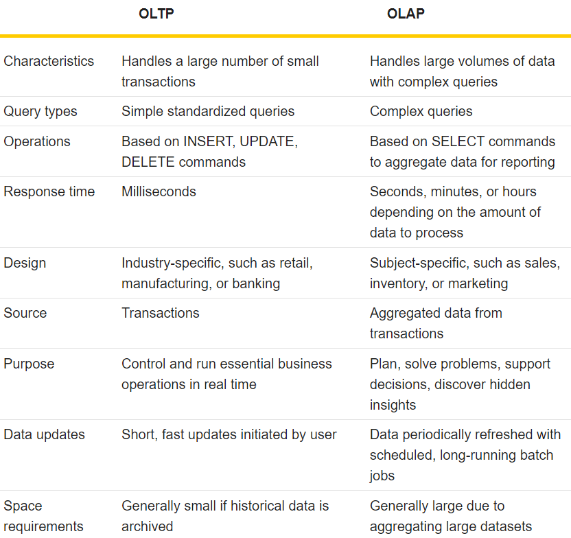

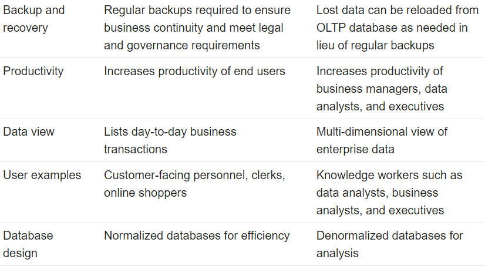

# 2) Partitioning and Clustering in BigQuery

https://towardsdatascience.com/how-to-use-partitions-and-clusters-in-bigquery-using-sql-ccf84c89dd65  
https://www.youtube.com/watch?v=-CqXf7vhhDs&list=PL3MmuxUbc_hJed7dXYoJw8DoCuVHhGEQb&index=26

# 3) BigQuery Best Practices

- Avoid SELECT *
- Price your queries before running them
- Use Partitioning/Clustering
- Use Streaming Inserts with caution - Can increase cost drastically
- Materialize queries into different stages

https://www.youtube.com/watch?v=k81mLJVX08w&list=PL3MmuxUbc_hJed7dXYoJw8DoCuVHhGEQb&index=27